# Activity Monitoring

## 3) What is the average daily activity pattern?

### Timeseries plot

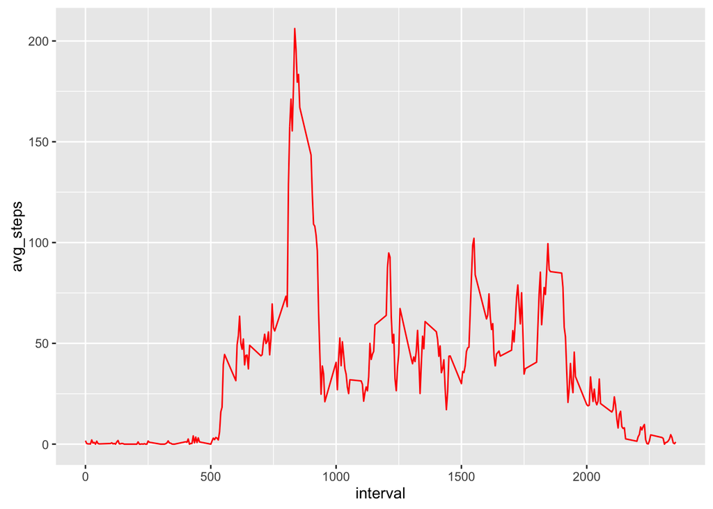

```r
grpint<-group_by(pam, interval)
sumint<-summarise(grpint, mean(steps, na.rm = TRUE))
colnames(sumint)[2]<-"avg_steps"

q<-ggplot(sumint, aes(interval, avg_steps))
q+geom_line(color="red", size=0.5)
```

### Which 5 min interval on average across all days contains a maximum number of steps?

```r
max<-subset(sumint, avg_steps==max(sumint$avg_steps))
max
```

```
## # A tibble: 1 × 2
##   interval avg_steps
##      <int>     <dbl>
## 1      835  206.1698
```

## 4) Imputing missing values

### Calculate number of lines with NA for steps

```r
sum(is.na(pam$steps))
```

```
## [1] 2304
```

### Devise a strategy to fill in the missing values

NA values could be replaced by interval average per observed day

### Create a new dataset with the missing values filled

```r
pam2<-pam
pam2[is.na(pam$steps),1]<-subset(sumint$avg_steps, sumint$interval%in%pam2$interval)
head(pam2)
```

```
##       steps       date interval
## 1 1.7169811 2012-10-01        0
## 2 0.3396226 2012-10-01        5
## 3 0.1320755 2012-10-01       10
## 4 0.1509434 2012-10-01       15
## 5 0.0754717 2012-10-01       20
## 6 2.0943396 2012-10-01       25
```

### Histogram of total number of steps per day

```r
grppam2<-group_by(pam2, date)
sumpam2<-summarize(grppam2, sum(steps))
colnames(sumpam2)[2]<-"total"
head(sumpam2)
```

```
## # A tibble: 6 × 2
##         date    total
##       <fctr>    <dbl>
## 1 2012-10-01 10766.19
## 2 2012-10-02   126.00
## 3 2012-10-03 11352.00
## 4 2012-10-04 12116.00
## 5 2012-10-05 13294.00
## 6 2012-10-06 15420.00
```

```r
summary(sumpam2)
```

```
##          date        total
##  2012-10-01: 1   Min.   :   41
##  2012-10-02: 1   1st Qu.: 9819
##  2012-10-03: 1   Median :10766
##  2012-10-04: 1   Mean   :10766
##  2012-10-05: 1   3rd Qu.:12811
##  2012-10-06: 1   Max.   :21194
##  (Other)   :55
```

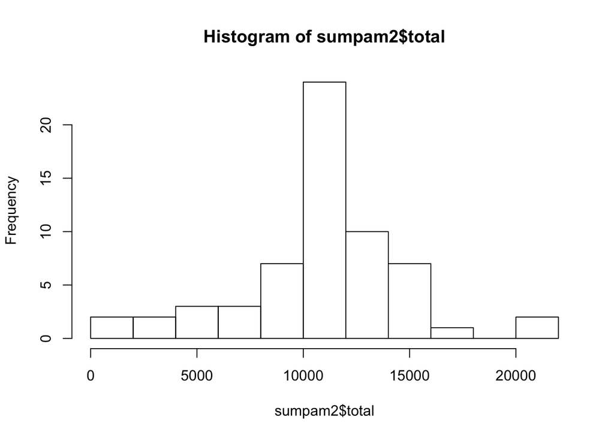

```r
hist(sumpam2$total, breaks=11)
```

```r
meansteps2<-mean(sumpam2$total, na.rm=TRUE)
mediansteps2<-median(sumpam2$total, na.rm=TRUE)
meansteps2
```

```
## [1] 10766.19
```

```r
mediansteps2
```

```
## [1] 10766.19
```

The impact of imputing the missing values is that the median increases, and becomes equal to the mean. There is no change to the mean between original and imputed values, as average calculations were used.

## 5) Are there differences in activity patterns between weekdays and weekends?

```r
pam3<-mutate(pam2, weekend=is.weekend(date))
head(pam3)
```

```
##       steps       date interval weekend
## 1 1.7169811 2012-10-01        0   FALSE
## 2 0.3396226 2012-10-01        5   FALSE
## 3 0.1320755 2012-10-01       10   FALSE
## 4 0.1509434 2012-10-01       15   FALSE
## 5 0.0754717 2012-10-01       20   FALSE
## 6 2.0943396 2012-10-01       25   FALSE
```

```r
grppam3<-group_by(pam3, interval, weekend)
sumint3<-summarise(grppam3, mean(steps))
colnames(sumint3)[3]<-"avg"
head(sumint3)
```

```
## Source: local data frame [6 x 3]
## Groups: interval [3]
##
##   interval weekend        avg
##      <int>   <lgl>      <dbl>
## 1        0   FALSE 2.25115304
## 2        0    TRUE 0.21462264
## 3        5   FALSE 0.44528302
## 4        5    TRUE 0.04245283
## 5       10   FALSE 0.17316562
## 6       10    TRUE 0.01650943
```

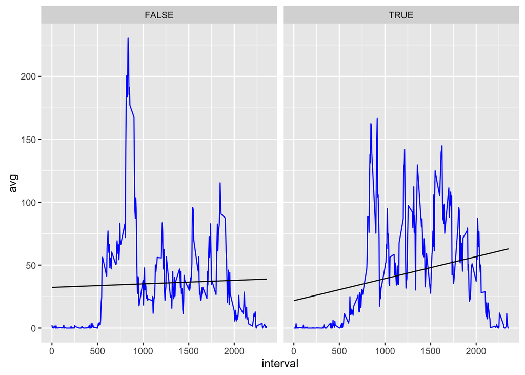

```r
g<-ggplot(sumint3, aes(interval, avg), color=weekend)
g+facet_grid(.~weekend)+geom_line(color="blue")+geom_smooth(method="lm", se=F, size=0.5, color="black")
```

In the graph above, FALSE indicates it is a weekday, and TRUE indicates it is a weekend.